# Homework #1: Supervised Learning

Meng Hua(mh2td)

Due: Mon Feb 15 | 10:55am

**SYS 4582/6018 | Spring 2021 | University of Virginia**

# Required R packages and Directories

```r
data.dir = 'https://mdporter.github.io/SYS6018/data/' # data directory
library(R6018)     # functions for SYS-6018
library(tidyverse) # functions for data manipulation
```

# Problem 1: Evaluating a Regression Model

## a. Create a set of functions to generate data from the following distributions:

$$\begin{align*}
X &\sim \mathcal{N}(0, 1) \\
Y &= -1 + .5X + .2X^2 + \epsilon \\
\epsilon &\sim \mathcal{N}(0,\, \sigma)
\end{align*}$$

```r
sim_x<-function(n) rnorm(n,0,1)
Ytrue<-function(X) -1+0.5*X+0.2*X**2
data<-function(sigma,n){
  tibble(x = sim_x(n),
         y = Ytrue(x) + rnorm(n,0,sigma))
}
```

## b. Simulate $n=100$ realizations from these distributions using $\sigma=3$. Produce a scatterplot and draw the true regression line $f(x) = E[Y \mid X=x]$.

- Use `set.seed(611)` prior to generating the data.

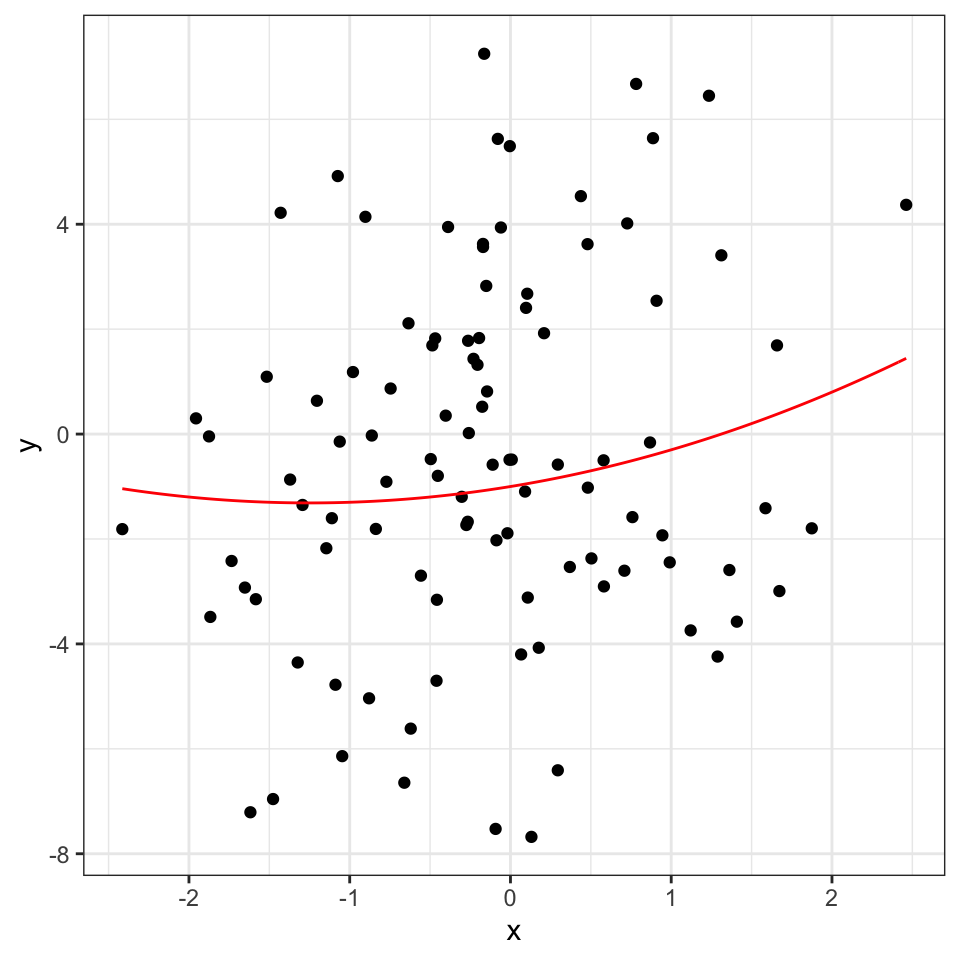

```r
set.seed(611)
n = 100
sigma = 3
dataset = data(sigma, n)

datavisual = ggplot(dataset,aes(x, y)) + geom_point() + stat_function(fun = Ytrue, color = "red")

datavisual
```

## c. Fit three polynomial regression models using least squares: linear, quadratic, and cubic. Produce another scatterplot, add the fitted lines and true population line $f(x)$ using different colors, and add a legend that maps the line color to a model.

- Note: The true model is quadratic, but we are also fitting linear (less complex) and cubic (more complex) models.

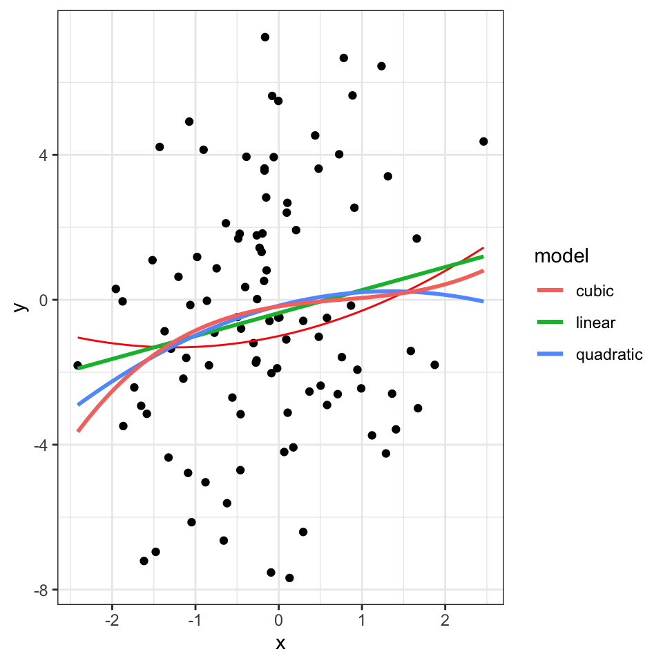

```r
datavisual +
 geom_smooth(method="lm",formula = "y ~ x" ,se=FALSE,aes(color="linear")) +
  geom_smooth(method="lm", formula="y~poly(x,2)", se=FALSE, aes(color="quadratic")) +
  geom_smooth(method="lm", formula="y~poly(x,3)", se=FALSE, aes(color="cubic")) +
  scale_color_discrete(name="model")
```

## d. Simulate a *test data* set of 10,000 observations from the same distributions. Use `set.seed(612)` prior to generating the test data.

- Calculate the estimated mean squared error (MSE) for each model.
- Are the results as expected?

```r
set.seed(612)
n = 10000
test_data = data(sigma,n)


poly_eval <- function(deg, data_train, data_test){
  if(deg==0) m = lm(y~1, data=data_train)  # intercept only model
  else m = lm(y~poly(x, degree=deg), data=data_train)# polynomial
  yhat = predict(m, newdata=data_test)     # predictions at test X's
  mean( (data_test$y - yhat)^2 )# test MSE
}
poly_eval(0, dataset,test_data)
```

```
#> [1] 9.41
```

```r
poly_eval(1, dataset,test_data)
```

```
#> [1] 9.294
```

```r
poly_eval(2, dataset,test_data)
```

```
#> [1] 9.583
```

```r
poly_eval(3, dataset,test_data)
```

```
#> [1] 9.648
```

- Are the results as expected? No. We would expect quadratic model to give smallest MSE because we generate data from a quadratic model. However, the linear model gives the best MSE.

## e. What is the best achievable MSE? That is, what is the MSE if the true $f(x)$ was used to evaluate the test set? How close does the best method come to achieving the optimum?

```r
yhat = Ytrue(test_data$x)
bestMSE = mean((yhat-test_data$y)^2)



bestMSE
```

```
#> [1] 8.972
```

-How close does the best method come to achieving the optimum?

```r
poly_eval(1, dataset,test_data) - bestMSE
```

```
#> [1] 0.3217
```

```r
poly_eval(2, dataset,test_data) - bestMSE
```

```
#> [1] 0.611
```

```r
poly_eval(3, dataset,test_data) - bestMSE
```

```
#> [1] 0.6761
```

The best method is linear model and it have the smallest difference between the bestMSE.

## f. The MSE scores obtained in part *d* came from one realization of training data. Here will we explore how much variation there is in the MSE scores by replicating the simulation many times.

- Re-run the same simulation in part *d* 100 times.
- Create kernel density or histogram plots of the resulting MSE values for each model.
- Use `set.seed(613)` prior to running the simulation and do not set the seed in any other places.

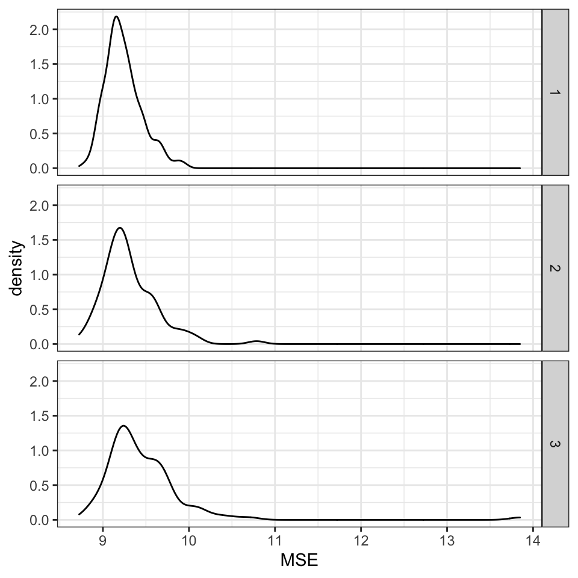

```r
set.seed(613)
sigma = 3
ntrain = 100
ntest = 10000
n = 100
data_poly = tibble(deg=numeric(),MSE=numeric())

best_model = numeric(length = 3)

for (j in c(1:100)) {
  data_train = data(sigma,ntrain)
  data_test = data(sigma,ntest)
  res <- numeric(length = 3)
  for (variable in c(1,2,3)) {
    tempMSE = poly_eval(variable,data_train = data_train,data_test = data_test)
    res[variable]<- tempMSE
    data_poly = add_row(data_poly,deg = variable, MSE = tempMSE)
  }
  best_model[which.min(res)] = best_model[which.min(res)]+1
}

ggplot(data=data_poly, aes(x=MSE, group=deg)) +
    geom_density() +facet_grid(deg ~ .)
```

## g. Show a count of how many times each model was the best. That is, out of the 100 simulations, count how many times each model had the lowest MSE.

```r
tibble("linear" = best_model[1], "quadratic"  = best_model[2], "cubic" =  best_model[3])
```

| linear | quadratic | cubic |
| --- | --- | --- |
| 44 | 50 | 6 |

## h. Repeat the simulation in part *f*, but use $\sigma=2$. Report the number of times each model was best (you do not need to produce any plots). Use the same `set.seed(613)` prior to running the simulation and do not set the seed in any other places.

```r
set.seed(613)
sigma = 2
ntrain = 100
ntest = 10000
n = 100

best_model = numeric(length = 3)

for (j in c(1:n)) {
  data_train = data(sigma,ntrain)
  data_test = data(sigma,ntest)
  res <- numeric(length = 3)
  for (variable in c(1,2,3)) {
    tempMSE = poly_eval(variable,data_train = data_train,data_test = data_test)
    res[variable]<- tempMSE
  }
  best_model[which.min(res)] = best_model[which.min(res)]+1
}

tibble("linear" = best_model[1], "quadratic"  = best_model[2], "cubic" =  best_model[3])
```

| linear | quadratic | cubic |
| --- | --- | --- |
| 26 | 66 | 8 |

## i. Repeat *h*, but now use $\sigma=4$ and $n=200$.

```r
set.seed(613)
sigma = 4
ntrain = 200
ntest = 10000
n =100


best_model = numeric(length = 3)

for (j in c(1:n)) {
  data_train = data(sigma,ntrain)
  data_test = data(sigma,ntest)
  res <- numeric(length = 3)
  for (variable in c(1,2,3)) {
    tempMSE = poly_eval(variable,data_train = data_train,data_test = data_test)
    res[variable]<- tempMSE

  }
  best_model[which.min(res)] = best_model[which.min(res)]+1
}

tibble("linear" = best_model[1], "quadratic"  = best_model[2], "cubic" =  best_model[3])
```

| linear | quadratic | cubic |
| --- | --- | --- |
| 23 | 67 | 10 |

## j. Describe the effects $\sigma$ and $n$ has on selection of the best model? Why is the *true* model form (i.e., quadratic) not always the *best* model to use when prediction is the goal?

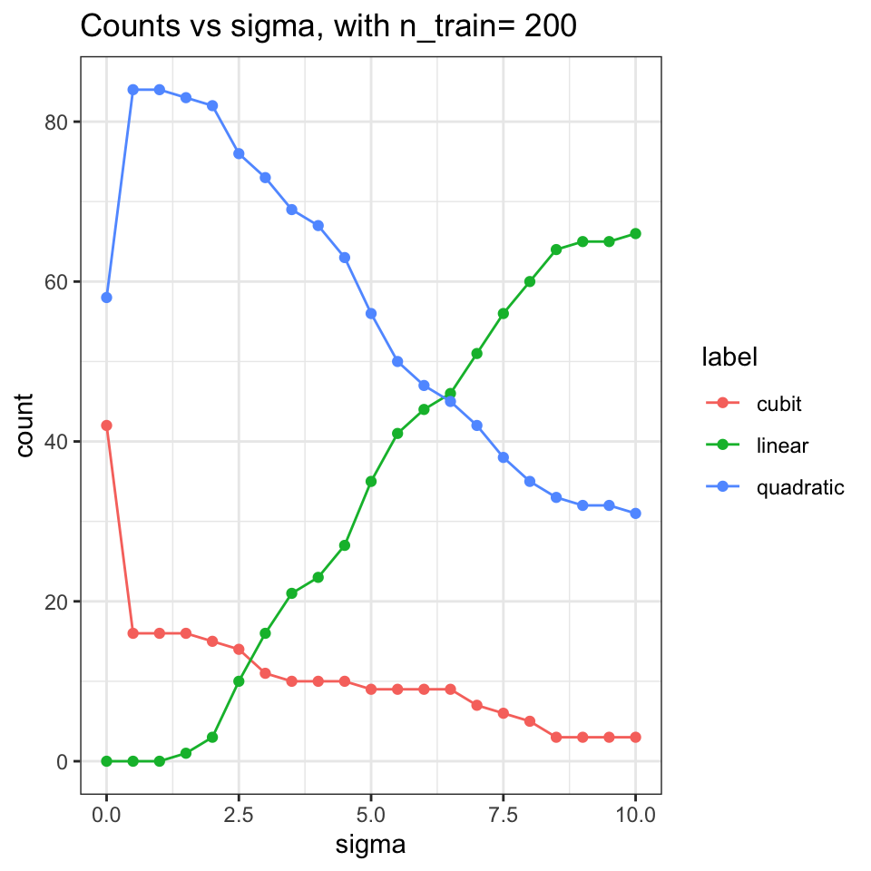

```r
vary_sigma<-function(sigma,ntrain){
  set.seed(613)
  ntest = 10000
  n =100


  best_model = numeric(length = 3)

  for (j in c(1:n)) {
    data_train = data(sigma,ntrain)
    data_test = data(sigma,ntest)
    res <- numeric(length = 3)
    for (variable in c(1,2,3)) {
      tempMSE = poly_eval(variable,data_train = data_train,data_test = data_test)
      res[variable]<- tempMSE

    }
    best_model[which.min(res)] = best_model[which.min(res)]+1
  }
  best_model
}

label_set = c("linear","quadratic","cubit")
ntrain = 200


change_sigma = tibble(sigma = numeric(),count = numeric(),label = character())
for (sd in seq(0,10,by=0.5)) {
  best_model = vary_sigma(sd, ntrain)
  for (label in c(1:3)) {
    change_sigma = add_row(change_sigma,sigma = sd, count = best_model[label], label = label_set[label] )
  }

}

sd = 3
change_ntrain = tibble(n_train = numeric(),count = numeric(),label = character())
for (ntrain in seq(100,1000,by=100)) {
  best_model = vary_sigma(sd, ntrain)
  for (label in c(1:3)) {
    change_ntrain = add_row(change_ntrain,n_train = ntrain, count = best_model[label], label = label_set[label] )
  }

}


ggplot(data = change_sigma, aes(x = sigma, y = count, group = label, color = label)) + geom_line() + geom_point()+labs(title = paste("Counts vs sigma, with n_train=",200))
```

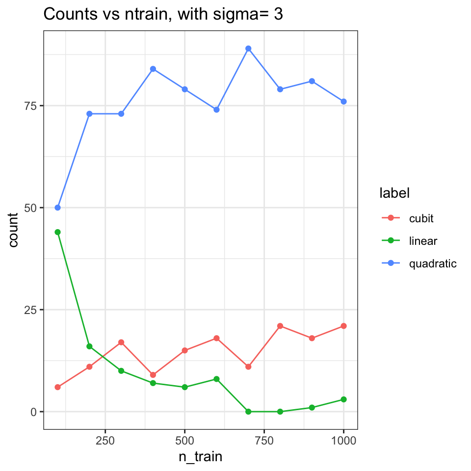

```r
ggplot(data = change_ntrain, aes(x = n_train, y = count, group = label, color = label)) + geom_line() + geom_point()+labs(title = paste("Counts vs ntrain, with sigma=", sd))
```

As $\sigma$ increases, the $\epsilon$ term will dominate in data generation and the data will deviate from our original quadratic model. So later on, the linear model will have better MSE.

If we have sufficient data, the number of training set ($n$) will not influence the best model. The result is stable.

Sometimes the best model will be linear. Because of the variance in selecting testing data. There will be some fluctuation.